# Primer on occupancy analysis

Michael E. Colvin

29 June 2016

# The process

Suppose you are out in the field at a specific location (note-occupancy makes inference about the site being occupied or not) and you repeated sample that site for a critter. It is likely you do not perfectly detect that critter if it is there, but you can detect it with some probability. Lets assume you can perfectly detect the critter then the detection history would be 1111 if you went out on 4 occasions. If you have imperfect detection, let’s define detection probability as $p$, then there is some probability you might miss detecting the critter even if it is there. Now that brings up a the foundation of occupancy analysis, you can miss a critter for 2 reasons: 1) that critter was not there to begin with (i.e., was not occupying the site) or 2) the critter was there (i.e., was occupying the site) but you did not detect it. These 2 sources of 0s in a detection history can either be a true negative (reason 1 above) or a false negative (reason 2 above).

# Probability of a site being occupied

In this context, occupancy as we observe it, is a 0 or 1. However as we think about occupancy or try to model occupancy it is done as a probability. Lets define the probability of a site being occupied as $\psi$. Let’s assume that we can detect our critter perfectly and $p = 1$. Now, if we have a $\psi = 0.35$, the probability of site not being occupied is $1=\psi$ or 1-0.35 = 0.65. Recall that occupancy is site or habitat specific and therefore the true site occupancy status (0 or 1) and therfore occupancy for 10 sites might be 111000000 for 10 sites given a $\psi = 0.35$. We can actually simulate this easily in r. Suppose there are potential 3000 sites to sample in a large tract of land (i.e., the sampling domain). But we can only sample 35 of those sites due to budget limitations. Lets simulate this to see how things play out

```r
psi<- 0.35 # set occupancy probability to 0.35
samp_domain<- 3000
site_status<- rbinom(samp_domain,1,psi)
table(site_status) # should be close to psi*3000 and (1-psi)*3000
```

```
## site_status
##    0    1
## 1916 1084
```

```r
mean(site_status)# should be close to psi
```

```
## [1] 0.3613333
```

For clarity lets make the status into a data.frame and number each site.

```r
sites<- data.frame(id=c(1:samp_domain), occupied=site_status)
# lets look at the first 10 rows of the data.frame
head(sites,10)
```

```
##    id occupied
## 1   1        1
## 2   2        1
## 3   3        1
## 4   4        0
## 5   5        0
## 6   6        0
## 7   7        0
## 8   8        1
## 9   9        0
## 10 10        0
```

Now that we know what our sites are for occupancy status we can sample 35 of them to estimate occupancy! Remember we are assuming that $p=1$ for now! The column “occupied” is the true occupancy status.

```r
# the sample function takes a random sample
# of 35 sites without replacement
my_sample<- sample(sites$id, 35,replace=FALSE)
my_srs<- sites[which(sites$id %in% my_sample),]# get the samples
# look at our sites
my_srs
```

```
##        id occupied
## 58     58        0
## 64     64        0
## 85     85        1
## 209   209        0
## 261   261        1
## 329   329        1
## 331   331        0
## 346   346        0
## 442   442        0
## 558   558        0
## 562   562        0
## 818   818        1
## 907   907        0
## 1014 1014        0
```

[output cut: 21 more lines]

Now we can do just as we did before, but now we are estimating occupancy.

```r
table(my_srs$occupied) # should be close to psi*35 and (1-psi)*35
```

```
##
##  0  1
## 26  9
```

```r
mean(my_srs$occupied)# should be close to psi
```

```
## [1] 0.2571429
```

Recall that $p = 1$. So if we went out 4 times to the 35 sites we randomly selected the detection history would be 1111 becuase there is no chance we might miss detecting the critter. But lets prove this using simulation. Keep in mind that it is the site that is occupied so detection is conditional on whether or not a site is occupied. In other words you cannot detect a critter that is not there. This can be confusing… conditional? Hopefully some simulation will clarify this.  
To simulate this we use the rbinom() function again to simulate 0 and 1 where the 0s and 1s correspond detecting the critter. For this example we will go out on 4 occasions.

```r
p<-1
occasion1<- rbinom(35,1,my_srs$occupied*p) # occasion 1
occasion2<- rbinom(35,1,my_srs$occupied*p) # occasion 2
occasion3<- rbinom(35,1,my_srs$occupied*p) # occasion 3
occasion4<- rbinom(35,1,my_srs$occupied*p) # occasion 4
```

Now we can put those together as a matrix of capture histories with each row represnting sites and each column representing occasion.

```r
detections<- cbind(occasion1,occasion2,occasion3,occasion4)
# lets look at the detections
detections
```

```
##       occasion1 occasion2 occasion3 occasion4
##  [1,]         0         0         0         0
##  [2,]         0         0         0         0
##  [3,]         1         1         1         1
##  [4,]         0         0         0         0
##  [5,]         1         1         1         1
##  [6,]         1         1         1         1
##  [7,]         0         0         0         0
##  [8,]         0         0         0         0
##  [9,]         0         0         0         0
## [10,]         0         0         0         0
## [11,]         0         0         0         0
## [12,]         1         1         1         1
## [13,]         0         0         0         0
## [14,]         0         0         0         0
```

[output cut: 21 more lines]

The big thing that you will notice above is that there are sites that are all 0s! This is where the conditional detection probability comes in, you cannot detect something that is not there, at least that is what we are assuming!

What happens when $p < 1$? Well we can simulat that too by simply changing $p$ in the r code. Now lets do something extreme and pretend we can only detect the critter if it is there with a probability of 0.20.

```r
p<-0.2
occasion1<- rbinom(35,1,my_srs$occupied*p)
occasion2<- rbinom(35,1, my_srs$occupied*p)
occasion3<- rbinom(35,1, my_srs$occupied*p)
occasion4<- rbinom(35,1, my_srs$occupied*p)
detections<- cbind(occasion1,occasion2,occasion3,occasion4)
detections # lets look at the detections
```

```
##       occasion1 occasion2 occasion3 occasion4
##  [1,]         0         0         0         0
##  [2,]         0         0         0         0
##  [3,]         0         0         0         0
##  [4,]         0         0         0         0
##  [5,]         1         0         0         0
##  [6,]         1         0         0         0
##  [7,]         0         0         0         0
##  [8,]         0         0         0         0
##  [9,]         0         0         0         0
## [10,]         0         0         0         0
## [11,]         0         0         0         0
## [12,]         0         0         0         0
## [13,]         0         0         0         0
## [14,]         0         0         0         0
```

[output cut: 21 more lines]

You will see now that there are alot more 0s in the mix compared to when $p = 1$! But the one thing that remains that same is that sites where the ‘true’ occupancy status is 0 remain as ‘0000’ but now we may have a few instance where site occupancy = 1 but the detection history is ‘0000’ as well.

We can look at those instances by figuring out by binding the column of occupancy status for each site to the detection history.

```r
cbind(detections, my_srs$occupied)
```

```
##       occasion1 occasion2 occasion3 occasion4
##  [1,]         0         0         0         0 0
##  [2,]         0         0         0         0 0
##  [3,]         0         0         0         0 1
##  [4,]         0         0         0         0 0
##  [5,]         1         0         0         0 1
##  [6,]         1         0         0         0 1
##  [7,]         0         0         0         0 0
##  [8,]         0         0         0         0 0
##  [9,]         0         0         0         0 0
## [10,]         0         0         0         0 0
## [11,]         0         0         0         0 0
## [12,]         0         0         0         0 1
## [13,]         0         0         0         0 0
## [14,]         0         0         0         0 0
```

[output cut: 21 more lines]

Now you can look at what sites are occupied but the critter was not detected!

## Naive occupancy estimates

A naive way to estimate occupancy is to determine sites where the critte was deteced in 1 or more occasions and use that as an occupancy estimate. Let’s see how that goes here, recall that $\psi = 0.35$ and therefore this naive estimate should be close or else the estimate is biased.

```r
no_detections<- rowSums(detections)# how many detections
occupied<- ifelse(no_detections>0,1,0) # assign sites as occupied or not
mean(occupied)
```

```
## [1] 0.1142857
```

Well that 0.1142857 is not equal to 0.35! Infact that is the whole reason for occupancy models, occupancy estimates are *underestimated* if $p< 1$!

Imagine if you had only done 1 occasion, the estimated occupancy would have been 0.0857143 which is even worse! This is what happens most of the time, single occasions, so lets explore the consequences of this on estimated occupancy.

Lets explore this for a range of $p$ from 0.1 to 1 to examine that effect, recall that $\psi= 0.35$.

```r
psi<-0.35
p<- seq(0.1,1,0.1)
p
```

```
##  [1] 0.1 0.2 0.3 0.4 0.5 0.6 0.7 0.8 0.9 1.0
```

Now we can loop over $p$ to get an estimate of occupancy and the consequences of assuming perfect detection using our 35 sites.

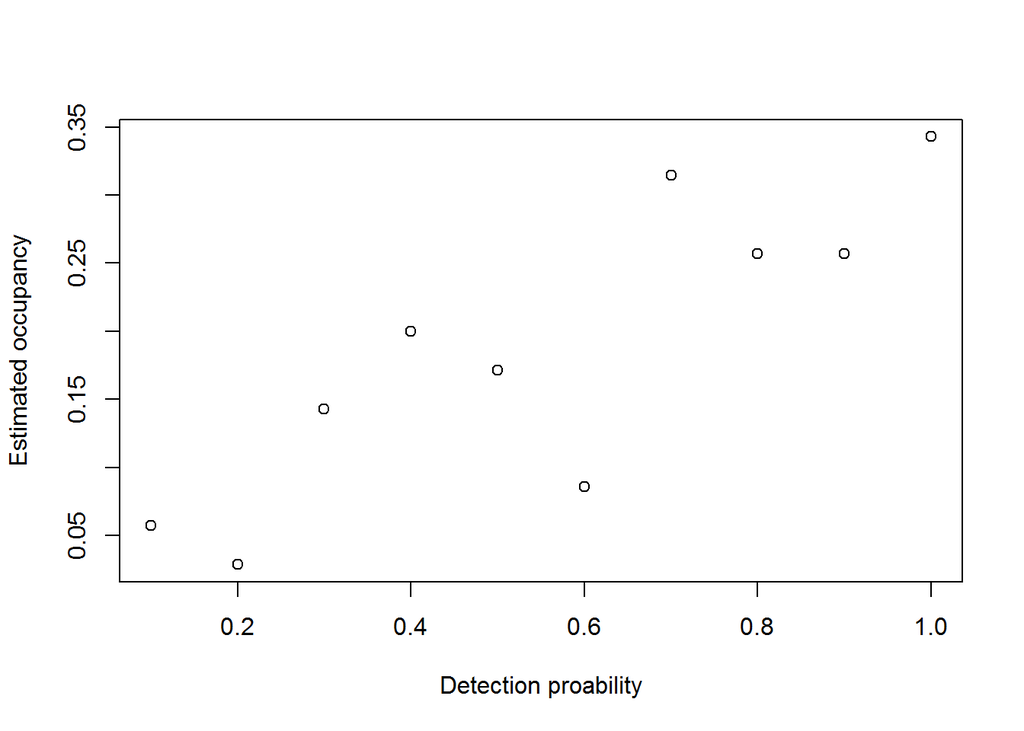

```r
occupancy_est<- c() # define object to save outputs to
for(i in 1:length(p))
    {
    occasion1<- rbinom(35,1,psi*p[i])
    occupancy_est<- c(occupancy_est,mean(occasion1))
    }
plot(p,occupancy_est,xlab="Detection proability",ylab="Estimated occupancy")
```

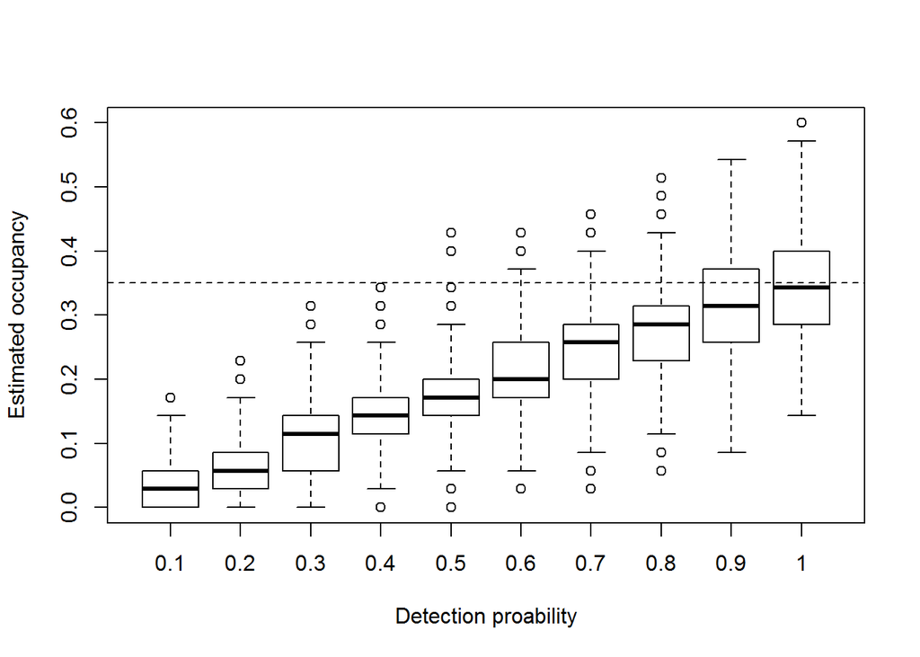

```r
occupancy_est<- matrix(NA,nrow=length(p),ncol=1000) # define matrix to save outputs to for 1000 replictes
for(i in 1:length(p))
    {
    for(rep in 1:1000)
        {
        occasion1<- rbinom(35,1,psi*p[i])
        occupancy_est[i,rep]<-mean(occasion1)
        }
    }
boxplot(t(occupancy_est),xlab="Detection proability",ylab="Estimated occupancy",names=p)
abline(h=psi,lty=2)
```

**So, as you can see from the boxplots occupancy estimates are negatively biased when $p < 1$!**

## Accounting for imperfect detection

Lets simulate our detection histories.

```r
p<-0.2
occasion1<- rbinom(35,1,my_srs$occupied*p)
occasion2<- rbinom(35,1, my_srs$occupied*p)
occasion3<- rbinom(35,1, my_srs$occupied*p)
occasion4<- rbinom(35,1, my_srs$occupied*p)
detections<- cbind(occasion1,occasion2,occasion3,occasion4)
detections # lets look at the detections
```

```
##       occasion1 occasion2 occasion3 occasion4
##  [1,]         0         0         0         0
##  [2,]         0         0         0         0
##  [3,]         0         0         0         0
##  [4,]         0         0         0         0
##  [5,]         0         0         0         0
##  [6,]         0         1         0         0
##  [7,]         0         0         0         0
##  [8,]         0         0         0         0
##  [9,]         0         0         0         0
## [10,]         0         0         0         0
## [11,]         0         0         0         0
## [12,]         1         0         0         0
## [13,]         0         0         0         0
## [14,]         0         0         0         0
```

[output cut: 21 more lines]

Ok, looks great, some 1s but mostly 0s.

Now lets fit an occupancy model to the data. First we need the unmarked package to do so.

Now we need to get our detecions into a matrix for unmarked.

```r
detections<-  unmarkedFrameOccu(detections, siteCovs=NULL, obsCovs=NULL)
detections
```

```
## Data frame representation of unmarkedFrame object.
##    y.1 y.2 y.3 y.4
## 1    0   0   0   0
## 2    0   0   0   0
## 3    0   0   0   0
## 4    0   0   0   0
## 5    0   0   0   0
## 6    0   1   0   0
## 7    0   0   0   0
## 8    0   0   0   0
## 9    0   0   0   0
## 10   0   0   0   0
## 11   0   0   0   0
## 12   1   0   0   0
## 13   0   0   0   0
```

[output cut: 22 more lines]

Note we do not have any site or observation covariates at this point and therefore they are NULL.

Now we can fit an occupancy model. Note that in the model equation the first tilda is for occupancy and the second is for detection. This becomes important once you are using covariates.

```r
fit <- occu(~ 1 ~ 1, detections)
fit
```

```
##
## Call:
## occu(formula = ~1 ~ 1, data = detections)
##
## Occupancy:
##  Estimate   SE       z P(>|z|)
##   -0.0392 1.67 -0.0234   0.981
##
## Detection:
##  Estimate   SE     z P(>|z|)
##     -2.18 1.01 -2.15  0.0317
##
## AIC: 59.07922
```

Well crappola that does not make much sense, $p$ was 0.2 and $\psi$ was 0.35 but the estimates are -0.0391632 for occupancy and -2.1752301 for detection proability.

We can extract the estimates from the fitted model as:

```r
coef(fit)[1]# occupancy
```

```
##    psi(Int)
## -0.03916321
```

```r
coef(fit)[2]# detection
```

```
##   p(Int)
## -2.17523
```

As is the case with most binary (0,1) data the linear models use a logit transformation and this estimates are on logit scale. If we want the actual values we need to simple take the estimate and run in through the equation $exp(est)/(1+exp(est))$

```r
occ_est_lo<- coef(fit)[1]# occupancy logit
exp(occ_est_lo)/(1+exp(occ_est_lo)) # it is close to 0.35!
```

```
##  psi(Int)
## 0.4902104
```

```r
det_est_lo<- coef(fit)[2]# detection logit
exp(det_est_lo)/(1+exp(det_est_lo)) # it is close to 0.2!
```

```
##   p(Int)
## 0.101997
```

Fortunately unmarked can do that for you as well.

```r
backTransform(fit, type="state")
```

```
## Backtransformed linear combination(s) of Occupancy estimate(s)
##
##  Estimate    SE LinComb (Intercept)
##      0.49 0.418 -0.0392           1
##
## Transformation: logistic
```

```r
backTransform(fit, type="det")
```

```
## Backtransformed linear combination(s) of Detection estimate(s)
##
##  Estimate     SE LinComb (Intercept)
##     0.102 0.0927   -2.18           1
##
## Transformation: logistic
```